# Measures of variation

The change in the value of a characteristic from one unit of the population to another in statistics is called the **variation** of a characteristic. In addition to average values to analyze the initial population calculate absolute and relative variation indices.

Absolute indicators include:

## Range of variation

1. **Range of variation (R)** is defined as the difference between the maximum and minimum values of a trait in the original population.
   $$R=x_{max}-x_{min}$$

## Middle Quartile Deviation

2. **Middle Quartile Deviation**. Defined as half of the difference between the 3rd quartile and the 1st quartile:
   $$\overline{Q}=\frac{Q_3-Q_1}{2}$$

## Linear mean deviation ($d$)

3. **Linear mean deviation ($d$)** It is defined as the arithmetic mean of absolute deviations of individual values of a trait from their average value. There are 2 formulas for ungrouped and grouped data.

For ungrouped data:
$$d=\frac{\sum\left|x_i-\overline{x}\right|}{n}$$

For grouped data:
$$d=\frac{\sum{\left|x_i-\overline{x}\right|f_i}}{\sum f_i}$$

## Dispersion ($\sigma^2$)

4. **Dispersion ($\sigma^2$)** It is defined as the arithmetic mean of the squares of deviations of individual values of a trait from the mean.

For ungrouped data:
$$\sigma^2=\frac{\sum\left(x_i-\overline{x}\right)^2}{n}$$

For grouped data:
$$\sigma^2=\frac{\sum{\left(x_i-\overline{x}\right)^2f_i}}{\sum f_i}$$

## Standard deviation

5. **Standard deviation** is the square root of the variance.

For ungrouped data:
$$\sigma=\sqrt{\sigma^2}=\sqrt{\frac{\sum\left(x_i-\overline{x}\right)^2}{n}}$$

For grouped data:
$$\sigma=\sqrt{\sigma^2}=\sqrt{\frac{\sum{\left(x_i-\overline{x}\right)^2f_i}}{\sum f_i}}$$

**Standard deviation** shows how much on average the individual values of a characteristic (variants) in the initial population differ from the average value. The indicator of mean square deviation is used in the assessment of possible risk in financial and economic calculations.

# Relative measures of variation include:

## Quartile variation coefficient

1. **Quartile variation coefficient,** which is calculated by the formula:
   $$V_{\overline{Q}}=\frac{\overline{Q}}{Me}\cdot100\%$$

## Oscillation Coefficient

2. **Oscillation Coefficient** :
   $$V_O=\frac{R}{\overline{x}}\cdot100\%$$

## Coefficient of variation

3. **Coefficient of variation** :
   $$V_\sigma=\frac{\sigma}{\overline{x}}\cdot100\%$$

the initial population is considered homogeneous by the studied characteristic if **the coefficient of variation is less than 33%**. In this case, the average value objectively represents its initial population.

## Coefficient of variation of linear mean deviation

4. **Coefficient of variation of linear mean deviation** :
   $$V_d=\frac{d}{\overline{x}}\cdot100\%$$

## Example of calculating variation indices:

| **Age of the deputy (full years) ($x$)** | **Number of deputies (number of people) (ƒ)** | **Interval midpoints ($x$)** | $\|x-\overline{x}\|$ | $\|x-\overline{x}\|f$ | $(x-\overline{x})^2f$ |
| --- | --- | --- | --- | --- | --- |
| 20-29 | 1 | 24,5 | 23,2 | 23,2 | 538,24 |
| 30-39 | 16 | 34,5 | 13,2 | 211,2 | 2787,84 |
| 40-49 | 28 | 44,5 | 3,2 | 89,6 | 286,72 |
| 50-59 | 30 | 54,5 | 6,8 | 204 | 1387,2 |
| 60-69 | 7 | 64,5 | 16,8 | 117,6 | 1975,68 |
| **Total:** | **82** | - | - | **645,6** | **6975,68** |

$$\overline{x}=47,7 \\
R=69-20=49 \: (лет) \\
d=\frac{\sum{\left|x_i-\overline{x}\right|f_i}}{\sum f_i} =7,9\:(лет) \\
\sigma^2=\frac{\sum{\left(x_i-\overline{x}\right)^2f_i}}{\sum f_i} = \frac{6975,68}{82}=85,07 \\
\sigma=\sqrt{85,07}=9,2\:(лет) \\
V_\sigma=\frac{9,2}{47,7}\cdot100\% = 19,3\% \\$$

On average, the age of each deputy differs from the average age for deputies of this faction by 9.2 years. This population of deputies is considered homogeneous by age, as the coefficient of variation is less than 33%.

## Mathematical properties of dispersion

1. The variance calculated with respect to the mean is the minimum variance.
2. The variance of a constant value is 0.
3. If all values of a trait (variants) are increased (decreased) by some constant number A, the variance of the new population will not change.
4. If all trait values (variants) are increased (multiplied) by K times, where K is a constant number, then the variance of the new population will increase (decrease) by $K^2$ times.
5. If the variance is calculated with respect to a number B different from the mean, then the variance of the original population can be calculated using the formula: $\sigma^2=σ_В^2-(\overline{x}-B)^2$.
6. The variance of the original population can be calculated as the difference between the mean of the squares of the trait and the square of the mean.

## Calculation of dispersion by the method of averages

This method of calculation is based on the last property of dispersion.

| **Age of the deputy (full years) ($x$)** | **Number of deputies (number of people) (ƒ)** | **Interval midpoints (x)** | **$x^2$** | **$x^2ƒ$** |
| --- | --- | --- | --- | --- |
| 20-29 | 1 | 24,5 | 600,25 | 600,25 |
| 30-39 | 16 | 34,5 | 1190,25 | 19044 |
| 40-49 | 28 | 44,5 | 1980,25 | 55447 |
| 50-59 | 30 | 54,5 | 2970,25 | 89107,5 |
| 60-69 | 7 | 64,5 | 4160,25 | 29121,75 |
| **Total:** | **82** | - | - | **193320,5** |

$$\overline{x^2}=\frac{\sum{x^2f}}{\sum f}=\frac{193320,5}{82}=2357,57 \\
\sigma^2=\overline{x^2}-{\overline{\left(x\right)}}^2=2357,57-(47,7)^2=82,3$$

## Three Sigma Rule

Under a normal distribution, there is a relationship between the value of $\sigma$ and the number of observations:

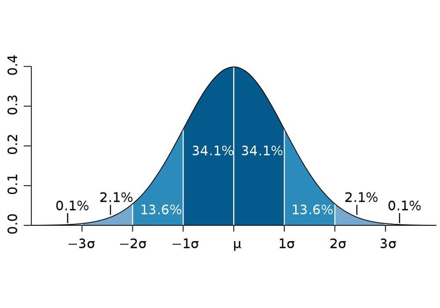

## Rules for summing dispersion

If the original population is divided into groups by some essential characteristic, the following types of dispersions are calculated:

## Total dispersions of the initial population

1. **Total dispersions of the initial population** by the formula:

$$\sigma^2=\frac{\sum{\left(x-\overline{x}\right)^2\cdot f}}{\sum f}$$
where:

- $\overline{x}$- the overall mean of the original population;
- $f$ - frequencies of the initial population. The total variance characterizes the deviation of individual values of a trait from the total mean of the initial population.

## Intra-group dispersions

2. **Intra-group dispersions** by the formula:
   $${\sigma_j}^2=\frac{\sum{\left(x-\overline{x_j}\right)^2\cdot f_j}}{\sum f_j}$$
   where:
- $j$ - group number;
- $\overline{x_j}$- mean value in each $j$-th group;
- $f_j$ - frequencies of the $j$-th group.

Intragroup dispersions characterize the deviation of the individual value of a trait in each group from the group average. From all **intragroup dispersions the average** is calculated by the formula:
$$\overline{{\sigma_j}^2}=\frac{\sum{{\sigma_j}^2\cdot n_j}}{\sum n_j}$$
Where:

- $n_j$- the number of units in each $j$-th group.

## Intergroup dispersions

3. **Intergroup dispersions** by the formula:
   $$\delta^2=\frac{\sum{\left(\overline{x_j}-\overline{x}\right)^2\cdot n_j}}{\sum n_j}$$

Intergroup dispersion characterizes the deviation of group averages from the overall average of the original population.

## The rule of adding variance

**The rule of adding variance** is that the total variance of the original population should be equal to the sum of the intergroup variance and the average of the within-group variance:
$$\sigma^2=\delta^2+\overline{{\sigma_j}^2}$$

Specific characteristics:

- The total variance will generally be greater than the average of the group variance, which is due to the fact that when the total population of units is dissected into parts by some feature, more or less homogeneous groups are formed, resulting in a reduction in the variability of the features within each group;
- the average of group dispersions turns out to be less than the dispersion of the sign on the whole aggregate of units, and the difference between these indicators will be the greater the more homogeneous the groups are obtained as a result of dissection of the total population.

## Empirical coefficient of determination

If $\eta$=0, then the grouping feature has no effect on the resultant feature. If $\eta$=1, then the resultant sign changes only depending on the sign, which is the basis of grouping, and the influence of other factor signs is equal to zero.

**Coefficient of determination**

Indicates the proportion (specific weight) of the total variation of the studied attribute due to the variation of the grouping attribute:

$$\eta^2= \frac{\delta^2}{\sigma^2} \times 100 \%$$

## Dispersion of the alternative trait

**Alternative attribute** - an attribute possessed by some units and not possessed by other units in the population.

Along with the study of variation of quantitative attributes determine the variation of alternative attributes.

- **p** the share of population units possessing an alternative characteristic;
- **q** the share of population units not possessing an alternative characteristic.

$$p+q=1$$

The presence of a feature in the units of the population is indicated by the number 1, the absence of a feature - 0. Let’s calculate the average value of the alternative attribute:
$$\overline{x}=\frac{\sum x f}{\sum f}=\frac{1\cdot p+0\cdot q}{p+q}=p$$

The average value of an alternative trait is equal to the proportion of population units possessing that alternative trait. calculate the variance of the alternative trait:
$$\sigma^2=\frac{\sum{\left(x-\overline{x}\right)^2f}}{\sum f}=\frac{(1-p)^2\cdot p+(0-p)^2\cdot q}{p+q}=q^2p+p^2q=pq\cdot(q+p)=pq$$

The variance of an alternative attribute is equal to the product of the proportion of population units possessing this attribute and the proportion of population units not possessing this attribute.

# Indicators of the form of distribution

## Asymmetry (Skewness)

A symmetric distribution is one in which variants equidistant from the mean have equal frequencies. If the distribution is asymmetric, the frequencies of variants equidistant from the mean are not equal to each other.

To characterize asymmetry, a third-order normalized moment is used:
$$M_3 = \frac{\sum{\left(x_i-\overline{x}\right)^3f_i}}{\sum f_i} \\
A=\frac{M_3}{\sigma^3}$$

Also, for comparative analysis of the degree of asymmetry of several distributions, the relative index of asymmetry (asymmetry coefficient) can be calculated by next formula:
$$A_x= \frac{\overline{x} - M_0}{\sigma}$$

- Right-sided asymmetry: $A_x > 0, \overline{x}>M_e>M_0$
- Symmetric curve: $A_x = 0, \overline{x}=M_e=M_0$
- Left-sided asymmetry: $A_x < 0, \overline{x}<M_e<M_0$

[figure not shown]

The greater the absolute value of the relative asymmetry index, the greater the degree of beveling. It is considered that if the asymmetry coefficient is less than 0.25, the asymmetry is insignificant, if it is more than 0.5, the asymmetry is significant.

## Kurtosis

The kurtosis refers to the degree of islanding of a distribution, with the normal distribution taken as a reference. The characteristic of kurtosis is the normalized moment of the fourth order.

$$M_4 = \frac{\sum{\left(x_i-\overline{x}\right)^4f_i}}{\sum f_i} \\
E= \frac{M_4}{\sigma^4}-3$$

- For a normal distribution, $E = 0$.
- For distributions that are more isovalent than normal, $E > 0$,
- For more flat-topped distributions, $E < 0$

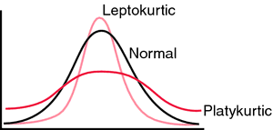